# 07. Transiciones de endeudamiento

- Mostrar todo el código
- Ocultar todo el código
- Ver el código fuente

Deuda total respecto del ingreso efectivo anual de los hogares

Autor/a

Gonzalo Torres

Fecha de publicación

27 de julio de 2026

# 1 Propósito

Este documento desarrolla un ejercicio longitudinal con el panel de la Encuesta Financiera de Hogares para 2007, 2011 y 2014.

El análisis estudia la relación entre dos magnitudes objetivas:

1. el monto total de deuda del hogar;
2. el ingreso total efectivo anual del hogar.

El cociente entre ambas corresponde a una medida de deuda sobre ingreso:

$$RDI =
\frac{\text{deuda total}}
{\text{ingreso efectivo mensual} \times 12}$$

La medida expresa cuántos años de ingreso efectivo representa el stock de deuda del hogar, suponiendo que el ingreso mensual se mantuviera constante.

No debe interpretarse como proporción del ingreso mensual destinada al pago de cuotas. Esa interpretación correspondería a una medida de carga financiera, que requiere información sobre pagos mensuales.

Para facilitar la exposición se construyen cuatro estados:

- sin deuda;
- deuda baja;
- deuda intermedia;
- deuda alta.

El interés principal está en observar:

- la distribución de estos estados en cada ola;
- cuánto permanecen o cambian los hogares;
- qué transiciones son más frecuentes;
- la dirección general de los movimientos;
- diferencias descriptivas según género y situación de pareja de la persona de referencia observada en 2014;
- las trayectorias completas entre 2007, 2011 y 2014.

# 2 Configuración del entorno

## 2.1 Paquetes

**Mostrar código**

```r
paquetes_necesarios <- c(
  "dplyr",
  "tidyr",
  "purrr",
  "stringr",
  "forcats",
  "tibble",
  "readr",
  "haven",
  "openxlsx",
  "here",
  "knitr",
  "ggplot2",
  "ggalluvial",
  "scales"
)

options(
  repos = c(
    CRAN = "https://cloud.r-project.org"
  ),
  dplyr.summarise.inform = FALSE,
  scipen = 999,
  stringsAsFactors = FALSE
)

paquetes_faltantes <- paquetes_necesarios[
  !paquetes_necesarios %in%
    rownames(
      installed.packages()
    )
]

if (
  length(
    paquetes_faltantes
  ) > 0
) {

  install.packages(
    paquetes_faltantes,
    repos = "https://cloud.r-project.org"
  )
}

invisible(
  lapply(
    paquetes_necesarios,
    library,
    character.only = TRUE
  )
)
```

# 3 Rutas del proyecto

**Mostrar código**

```r
ruta_proyecto <- normalizePath(
  here::here(),
  winslash = "/",
  mustWork = FALSE
)

ruta_datos <- here::here(
  "Datos",
  "EFH Panel"
)

ruta_salidas <- here::here(
  "outputs",
  "07_transiciones_deuda_ingreso"
)

ruta_tablas <- file.path(
  ruta_salidas,
  "tablas"
)

ruta_figuras <- file.path(
  ruta_salidas,
  "figuras"
)

ruta_objetos <- file.path(
  ruta_salidas,
  "objetos"
)

dir.create(
  ruta_tablas,
  recursive = TRUE,
  showWarnings = FALSE
)

dir.create(
  ruta_figuras,
  recursive = TRUE,
  showWarnings = FALSE
)

dir.create(
  ruta_objetos,
  recursive = TRUE,
  showWarnings = FALSE
)

ruta_efh_2014 <- file.path(
  ruta_datos,
  "Base no imputada EFH 2014.dta"
)

if (
  !file.exists(
    ruta_efh_2014
  )
) {

  archivos_2014_candidatos <- list.files(
    path = ruta_datos,
    pattern = "2014.*\\.dta$|\\.dta$",
    full.names = TRUE,
    ignore.case = TRUE
  )

  if (
    length(
      archivos_2014_candidatos
    ) == 1
  ) {

    ruta_efh_2014 <- archivos_2014_candidatos[[1]]

  } else {

    stop(
      paste0(
        "No se encontró de manera inequívoca la base EFH 2014.\n\n",
        "Archivo esperado:\n",
        file.path(
          ruta_datos,
          "Base no imputada EFH 2014.dta"
        ),
        "\n\nArchivos .dta encontrados:\n",
        paste(
          basename(
            archivos_2014_candidatos
          ),
          collapse = "\n"
        )
      )
    )
  }
}

cat(
  "Directorio del proyecto:\n",
  ruta_proyecto,
  "\n\n"
)
```

```
Directorio del proyecto:
 C:/Users/PC/OneDrive/Postgrados/OBDE/Taller Med Obj Subj
```

**Mostrar código**

```r
cat(
  "Directorio de datos EFH:\n",
  normalizePath(
    ruta_datos,
    winslash = "/",
    mustWork = FALSE
  ),
  "\n\n"
)
```

```
Directorio de datos EFH:
 C:/Users/PC/OneDrive/Postgrados/OBDE/Taller Med Obj Subj/Datos/EFH Panel
```

**Mostrar código**

```r
cat(
  "Base EFH 2014 seleccionada:\n",
  normalizePath(
    ruta_efh_2014,
    winslash = "/",
    mustWork = FALSE
  ),
  "\n"
)
```

```
Base EFH 2014 seleccionada:
 C:/Users/PC/OneDrive/Postgrados/OBDE/Taller Med Obj Subj/Datos/EFH Panel/Base no imputada EFH 2014.dta
```

# 4 Parámetros analíticos

Los puntos de corte pueden modificarse desde este bloque.

La clasificación principal distingue:

- sin deuda;
- deuda baja: deuda positiva y hasta 50% del ingreso anual;
- deuda intermedia: más de 50% y hasta 150%;
- deuda alta: más de 150% del ingreso anual.

**Mostrar código**

```r
limite_deuda_baja <- 0.50

limite_deuda_intermedia <- 1.50

anios_analisis <- c(
  2007L,
  2011L,
  2014L
)
```

# 5 Paleta y etiquetas

**Mostrar código**

```r
color_mostaza <- "#F2C94C"

color_mostaza_oscuro <- "#C99A20"

color_morado_claro <- "#A978B5"

color_morado_oscuro <- "#4B1F63"

color_gris_oscuro <- "#4D4D4D"

color_gris_medio <- "#A7A3AA"

color_gris_claro <- "#D9D9D9"

color_texto <- "#2E2E2E"

niveles_deuda <- c(
  "Sin deuda",
  "Deuda baja",
  "Deuda intermedia",
  "Deuda alta"
)

paleta_deuda <- c(
  "Sin deuda" =
    color_mostaza,

  "Deuda baja" =
    color_mostaza_oscuro,

  "Deuda intermedia" =
    color_morado_claro,

  "Deuda alta" =
    color_morado_oscuro
)

etiquetas_deuda_leyenda <- c(
  "Sin deuda" =
    "Sin deuda",

  "Deuda baja" =
    "Baja: hasta 50% del ingreso anual",

  "Deuda intermedia" =
    "Intermedia: 50% a 150% del ingreso anual",

  "Deuda alta" =
    "Alta: más de 150% del ingreso anual"
)

niveles_direccion <- c(
  "Disminuyó",
  "Permaneció",
  "Aumentó"
)

paleta_direccion_composicion <- c(
  "Disminuyó" =
    color_mostaza,

  "Permaneció" =
    color_gris_medio,

  "Aumentó" =
    color_morado_oscuro
)
```

# 6 Tema gráfico común

**Mostrar código**

```r
tema_taller <- function(
    tamano_base = 12
) {

  ggplot2::theme_minimal(
    base_size = tamano_base
  ) +
    ggplot2::theme(
      panel.grid.minor =
        ggplot2::element_blank(),

      panel.grid.major.x =
        ggplot2::element_blank(),

      plot.title =
        ggplot2::element_text(
          face = "bold",
          color = "#2B183B",
          size = tamano_base + 3,
          margin = ggplot2::margin(
            b = 8
          )
        ),

      plot.subtitle =
        ggplot2::element_text(
          color = "grey30",
          size = tamano_base,
          lineheight = 1.1,
          margin = ggplot2::margin(
            b = 12
          )
        ),

      plot.caption =
        ggplot2::element_text(
          color = "grey35",
          size = tamano_base - 2,
          hjust = 0,
          lineheight = 1.1,
          margin = ggplot2::margin(
            t = 12
          )
        ),

      plot.margin =
        ggplot2::margin(
          t = 18,
          r = 18,
          b = 20,
          l = 18
        ),

      legend.position =
        "bottom",

      legend.box =
        "vertical",

      legend.text =
        ggplot2::element_text(
          size = tamano_base - 1
        ),

      legend.title =
        ggplot2::element_text(
          face = "bold"
        )
    )
}
```

# 7 Funciones auxiliares

## 7.1 Conversión numérica segura

**Mostrar código**

```r
convertir_numerico <- function(
    x
) {

  if (
    inherits(
      x,
      "haven_labelled"
    )
  ) {

    x <- haven::zap_labels(
      x
    )
  }

  suppressWarnings(
    as.numeric(
      as.character(
        x
      )
    )
  )
}
```

## 7.2 Conversión de variables etiquetadas

**Mostrar código**

```r
convertir_etiquetado_a_texto <- function(
    x
) {

  if (
    inherits(
      x,
      "haven_labelled"
    )
  ) {

    return(
      as.character(
        haven::as_factor(
          x,
          levels = "default"
        )
      )
    )
  }

  if (
    is.factor(
      x
    )
  ) {

    return(
      as.character(
        x
      )
    )
  }

  as.character(
    x
  )
}
```

## 7.3 Normalización de texto

**Mostrar código**

```r
normalizar_texto <- function(
    x
) {

  x |>
    as.character() |>
    stringr::str_to_lower() |>
    stringr::str_replace_all(
      "[áàäâ]",
      "a"
    ) |>
    stringr::str_replace_all(
      "[éèëê]",
      "e"
    ) |>
    stringr::str_replace_all(
      "[íìïî]",
      "i"
    ) |>
    stringr::str_replace_all(
      "[óòöô]",
      "o"
    ) |>
    stringr::str_replace_all(
      "[úùüû]",
      "u"
    ) |>
    stringr::str_replace_all(
      "ñ",
      "n"
    ) |>
    stringr::str_squish()
}
```

## 7.4 Primer valor válido

**Mostrar código**

```r
primer_valor_valido <- function(
    x
) {

  valores_validos <- x[
    !is.na(
      x
    )
  ]

  if (
    length(
      valores_validos
    ) == 0
  ) {

    return(
      NA
    )
  }

  valores_validos[[1]]
}
```

## 7.5 Media ponderada segura

**Mostrar código**

```r
media_ponderada_segura <- function(
    x,
    ponderador
) {

  casos_validos <-
    !is.na(
      x
    ) &
    !is.na(
      ponderador
    ) &
    ponderador > 0

  if (
    sum(
      casos_validos
    ) == 0
  ) {

    return(
      NA_real_
    )
  }

  stats::weighted.mean(
    x[
      casos_validos
    ],
    ponderador[
      casos_validos
    ]
  )
}
```

## 7.6 Mediana ponderada

**Mostrar código**

```r
mediana_ponderada_segura <- function(
    x,
    ponderador
) {

  casos_validos <-
    !is.na(
      x
    ) &
    !is.na(
      ponderador
    ) &
    ponderador > 0

  if (
    sum(
      casos_validos
    ) == 0
  ) {

    return(
      NA_real_
    )
  }

  x_valido <- x[
    casos_validos
  ]

  w_valido <- ponderador[
    casos_validos
  ]

  orden <- order(
    x_valido
  )

  x_ordenado <- x_valido[
    orden
  ]

  w_ordenado <- w_valido[
    orden
  ]

  proporcion_acumulada <- cumsum(
    w_ordenado
  ) /
    sum(
      w_ordenado
    )

  x_ordenado[
    which(
      proporcion_acumulada >= 0.5
    )[1]
  ]
}
```

## 7.7 Limpieza UTF-8

**Mostrar código**

```r
limpiar_vector_utf8 <- function(
    x
) {

  if (
    is.factor(
      x
    )
  ) {

    x <- as.character(
      x
    )
  }

  if (
    !is.character(
      x
    )
  ) {

    return(
      x
    )
  }

  resultado <- suppressWarnings(
    iconv(
      x,
      from = "",
      to = "UTF-8",
      sub = NA
    )
  )

  posiciones_fallidas <-
    is.na(
      resultado
    ) &
    !is.na(
      x
    )

  if (
    any(
      posiciones_fallidas
    )
  ) {

    resultado[
      posiciones_fallidas
    ] <- suppressWarnings(
      iconv(
        x[
          posiciones_fallidas
        ],
        from = "windows-1252",
        to = "UTF-8",
        sub = ""
      )
    )
  }

  posiciones_aun_fallidas <-
    is.na(
      resultado
    ) &
    !is.na(
      x
    )

  if (
    any(
      posiciones_aun_fallidas
    )
  ) {

    resultado[
      posiciones_aun_fallidas
    ] <- suppressWarnings(
      iconv(
        x[
          posiciones_aun_fallidas
        ],
        from = "latin1",
        to = "UTF-8",
        sub = ""
      )
    )
  }

  resultado
}
```

## 7.8 Exportación segura

**Mostrar código**

```r
hacer_exportable <- function(
    datos
) {

  salida <- as.data.frame(
    datos
  )

  for (
    nombre_variable in
    names(
      salida
    )
  ) {

    variable <- salida[[
      nombre_variable
    ]]

    if (
      inherits(
        variable,
        "haven_labelled"
      )
    ) {

      salida[[
        nombre_variable
      ]] <- as.character(
        haven::as_factor(
          variable
        )
      )

    } else if (
      is.factor(
        variable
      )
    ) {

      salida[[
        nombre_variable
      ]] <- as.character(
        variable
      )
    }

    if (
      is.character(
        salida[[
          nombre_variable
        ]]
      )
    ) {

      salida[[
        nombre_variable
      ]] <- limpiar_vector_utf8(
        salida[[
          nombre_variable
        ]]
      )
    }
  }

  names(
    salida
  ) <- limpiar_vector_utf8(
    names(
      salida
    )
  )

  salida
}
```

# 8 Identificación de la base

**Mostrar código**

```r
archivos_candidatos <- c(
  file.path(
    ruta_datos,
    "efh_panel_balanceado_corregido.rds"
  ),

  file.path(
    ruta_datos,
    "efh_panel_balanceado_corregido.csv"
  ),

  file.path(
    ruta_datos,
    "efh_panel_tres_olas_corregido.rds"
  ),

  file.path(
    ruta_datos,
    "efh_panel_tres_olas_corregido.csv"
  )
)

archivos_encontrados <- archivos_candidatos[
  file.exists(
    archivos_candidatos
  )
]

if (
  length(
    archivos_encontrados
  ) == 0
) {

  archivos_disponibles <- list.files(
    ruta_datos,
    full.names = FALSE
  )

  stop(
    paste0(
      "No se encontró la base completa corregida del panel EFH en:\n",
      ruta_datos,
      "\n\nSe buscó alguno de estos archivos:\n",
      paste(
        basename(
          archivos_candidatos
        ),
        collapse = "\n"
      ),
      "\n\nArchivos actualmente disponibles:\n",
      paste(
        archivos_disponibles,
        collapse = "\n"
      )
    )
  )
}

archivo_panel <- archivos_encontrados[[1]]

cat(
  "Archivo seleccionado:\n",
  basename(
    archivo_panel
  ),
  "\n"
)
```

```
Archivo seleccionado:
 efh_panel_balanceado_corregido.csv
```

# 9 Lectura de la base

**Mostrar código**

```r
extension_archivo <- tolower(
  tools::file_ext(
    archivo_panel
  )
)

if (
  extension_archivo == "rds"
) {

  efh_panel <- readRDS(
    archivo_panel
  )

} else if (
  extension_archivo == "csv"
) {

  efh_panel <- readr::read_csv(
    archivo_panel,
    show_col_types = FALSE,
    progress = FALSE
  )

} else {

  stop(
    paste0(
      "La extensión ",
      extension_archivo,
      " no está contemplada."
    )
  )
}

efh_panel <- tibble::as_tibble(
  efh_panel
)

cat(
  "Filas:",
  nrow(
    efh_panel
  ),
  "\n"
)
```

```
Filas: 2982
```

**Mostrar código**

```r
cat(
  "Columnas:",
  ncol(
    efh_panel
  ),
  "\n"
)
```

```
Columnas: 44
```

**Mostrar código**

```r
cat(
  "Hogares:",
  dplyr::n_distinct(
    efh_panel$panel_id
  ),
  "\n"
)
```

```
Hogares: 994
```

# 10 Verificación de variables

**Mostrar código**

```r
variables_requeridas <- c(
  "panel_id",
  "id",
  "anio",
  "ingreso_total_efectivo",
  "deuda_total"
)

variables_faltantes <- setdiff(
  variables_requeridas,
  names(
    efh_panel
  )
)

if (
  length(
    variables_faltantes
  ) > 0
) {

  stop(
    paste0(
      "La base seleccionada no contiene las variables necesarias:\n",
      paste(
        variables_faltantes,
        collapse = ", "
      ),
      "\n\nAsegúrese de copiar a Datos/EFH Panel la base balanceada completa."
    )
  )
}
```

# 11 Preparación de variables opcionales

**Mostrar código**

```r
if (
  "factor" %in%
    names(
      efh_panel
    )
) {

  ponderador_panel <- convertir_numerico(
    efh_panel$factor
  )

} else {

  ponderador_panel <- rep(
    1,
    nrow(
      efh_panel
    )
  )
}

if (
  "imp" %in%
    names(
      efh_panel
    )
) {

  imputacion_panel <- convertir_numerico(
    efh_panel$imp
  )

} else {

  imputacion_panel <- rep(
    NA_real_,
    nrow(
      efh_panel
    )
  )
}
```

# 12 Base longitudinal inicial

**Mostrar código**

```r
base_panel <- efh_panel |>
  dplyr::transmute(
    panel_id =
      as.character(
        panel_id
      ),

    id =
      as.character(
        id
      ),

    anio =
      as.integer(
        convertir_numerico(
          anio
        )
      ),

    imp =
      imputacion_panel,

    ponderador =
      ponderador_panel,

    ingreso_efectivo_mensual =
      convertir_numerico(
        ingreso_total_efectivo
      ),

    deuda_total =
      convertir_numerico(
        deuda_total
      )
  ) |>
  dplyr::filter(
    anio %in%
      anios_analisis
  ) |>
  dplyr::mutate(
    ponderador =
      dplyr::case_when(
        is.na(
          ponderador
        ) ~ 1,

        ponderador <= 0 ~ 1,

        TRUE ~ ponderador
      ),

    ingreso_efectivo_anual =
      ingreso_efectivo_mensual *
        12
  ) |>
  dplyr::arrange(
    panel_id,
    anio
  )
```

# 13 Auditoría de duplicados

**Mostrar código**

```r
tabla_duplicados <- base_panel |>
  dplyr::count(
    panel_id,
    anio,
    name = "numero_registros"
  ) |>
  dplyr::filter(
    numero_registros > 1
  )

if (
  nrow(
    tabla_duplicados
  ) > 0
) {

  stop(
    paste0(
      "La base presenta duplicados por panel_id y año. ",
      "Revise el objeto tabla_duplicados."
    )
  )
}
```

# 14 Auditoría del identificador

**Mostrar código**

```r
tabla_id_panel <- base_panel |>
  dplyr::group_by(
    anio
  ) |>
  dplyr::summarise(
    hogares =
      dplyr::n_distinct(
        panel_id
      ),

    identificadores_id =
      dplyr::n_distinct(
        id
      ),

    id_perdidos =
      sum(
        is.na(
          id
        ) |
          id == ""
      ),

    .groups =
      "drop"
  )

knitr::kable(
  tabla_id_panel,
  caption = "Disponibilidad del identificador de hogar por ola"
)
```

Disponibilidad del identificador de hogar por ola

| anio | hogares | identificadores_id | id_perdidos |
| --- | --- | --- | --- |
| 2007 | 994 | 994 | 0 |
| 2011 | 994 | 994 | 0 |
| 2014 | 994 | 994 | 0 |

# 15 Auditoría de cobertura

**Mostrar código**

```r
tabla_cobertura <- base_panel |>
  dplyr::group_by(
    anio
  ) |>
  dplyr::summarise(
    hogares =
      dplyr::n_distinct(
        panel_id
      ),

    ingreso_valido =
      sum(
        !is.na(
          ingreso_efectivo_mensual
        ) &
          ingreso_efectivo_mensual > 0
      ),

    porcentaje_ingreso_valido =
      100 *
        mean(
          !is.na(
            ingreso_efectivo_mensual
          ) &
            ingreso_efectivo_mensual > 0
        ),

    deuda_valida =
      sum(
        !is.na(
          deuda_total
        ) &
          deuda_total >= 0
      ),

    porcentaje_deuda_valida =
      100 *
        mean(
          !is.na(
            deuda_total
          ) &
            deuda_total >= 0
        ),

    ingreso_y_deuda_validos =
      sum(
        !is.na(
          ingreso_efectivo_mensual
        ) &
          ingreso_efectivo_mensual > 0 &
          !is.na(
            deuda_total
          ) &
          deuda_total >= 0
      ),

    porcentaje_ambos_validos =
      100 *
        mean(
          !is.na(
            ingreso_efectivo_mensual
          ) &
            ingreso_efectivo_mensual > 0 &
          !is.na(
            deuda_total
          ) &
            deuda_total >= 0
        ),

    .groups =
      "drop"
  )
```

**Mostrar código**

```r
knitr::kable(
  tabla_cobertura |>
    dplyr::mutate(
      dplyr::across(
        dplyr::starts_with(
          "porcentaje"
        ),
        ~ round(
          .x,
          1
        )
      )
    ),
  caption = "Cobertura de ingreso efectivo y deuda total por ola"
)
```

Cobertura de ingreso efectivo y deuda total por ola

| anio | hogares | ingreso_valido | porcentaje_ingreso_valido | deuda_valida | porcentaje_deuda_valida | ingreso_y_deuda_validos | porcentaje_ambos_validos |
| --- | --- | --- | --- | --- | --- | --- | --- |
| 2007 | 994 | 987 | 99.3 | 814 | 81.9 | 807 | 81.2 |
| 2011 | 994 | 979 | 98.5 | 899 | 90.4 | 885 | 89.0 |
| 2014 | 994 | 827 | 83.2 | 867 | 87.2 | 742 | 74.6 |

# 16 Selección del panel analítico

**Mostrar código**

```r
disponibilidad_hogar <- base_panel |>
  dplyr::mutate(
    observacion_valida =
      !is.na(
        ingreso_efectivo_mensual
      ) &
        ingreso_efectivo_mensual > 0 &
      !is.na(
        deuda_total
      ) &
        deuda_total >= 0
  ) |>
  dplyr::group_by(
    panel_id
  ) |>
  dplyr::summarise(
    olas_observadas =
      dplyr::n_distinct(
        anio
      ),

    olas_validas =
      sum(
        observacion_valida
      ),

    panel_analitico =
      olas_observadas ==
        length(
          anios_analisis
        ) &
      olas_validas ==
        length(
          anios_analisis
        ),

    .groups =
      "drop"
  )
```

**Mostrar código**

```r
identificadores_analiticos <- disponibilidad_hogar |>
  dplyr::filter(
    panel_analitico
  ) |>
  dplyr::pull(
    panel_id
  )

base_analitica <- base_panel |>
  dplyr::filter(
    panel_id %in%
      identificadores_analiticos
  ) |>
  dplyr::arrange(
    panel_id,
    anio
  )
```

**Mostrar código**

```r
tabla_muestra <- tibble::tibble(
  indicador = c(
    "Hogares presentes en las tres olas",
    "Hogares con ingreso y deuda válidos en las tres olas",
    "Hogares excluidos por información incompleta",
    "Observaciones hogar-ola del panel analítico"
  ),

  valor = c(
    sum(
      disponibilidad_hogar$olas_observadas ==
        length(
          anios_analisis
        )
    ),

    length(
      identificadores_analiticos
    ),

    sum(
      disponibilidad_hogar$olas_observadas ==
        length(
          anios_analisis
        )
    ) -
      length(
        identificadores_analiticos
      ),

    nrow(
      base_analitica
    )
  )
)
```

**Mostrar código**

```r
knitr::kable(
  tabla_muestra,
  caption = "Construcción del panel analítico"
)
```

Construcción del panel analítico

| indicador | valor |
| --- | --- |
| Hogares presentes en las tres olas | 994 |
| Hogares con ingreso y deuda válidos en las tres olas | 547 |
| Hogares excluidos por información incompleta | 447 |
| Observaciones hogar-ola del panel analítico | 1641 |

# 17 Construcción de la razón deuda-ingreso

**Mostrar código**

```r
base_analitica <- base_analitica |>
  dplyr::mutate(
    razon_deuda_ingreso =
      dplyr::case_when(
        deuda_total == 0 ~
          0,

        deuda_total > 0 &
          ingreso_efectivo_anual > 0 ~
          deuda_total /
            ingreso_efectivo_anual,

        TRUE ~
          NA_real_
      ),

    estado_deuda =
      dplyr::case_when(
        deuda_total == 0 ~
          "Sin deuda",

        razon_deuda_ingreso > 0 &
          razon_deuda_ingreso <=
            limite_deuda_baja ~
          "Deuda baja",

        razon_deuda_ingreso >
          limite_deuda_baja &
          razon_deuda_ingreso <=
            limite_deuda_intermedia ~
          "Deuda intermedia",

        razon_deuda_ingreso >
          limite_deuda_intermedia ~
          "Deuda alta",

        TRUE ~
          NA_character_
      ),

    estado_deuda =
      factor(
        estado_deuda,
        levels = niveles_deuda,
        ordered = TRUE
      ),

    nivel_deuda_numerico =
      dplyr::case_when(
        estado_deuda == "Sin deuda" ~
          0L,

        estado_deuda == "Deuda baja" ~
          1L,

        estado_deuda == "Deuda intermedia" ~
          2L,

        estado_deuda == "Deuda alta" ~
          3L,

        TRUE ~
          NA_integer_
      )
  )
```

# 18 Auditoría de la razón deuda-ingreso

**Mostrar código**

```r
tabla_resumen_rdi <- base_analitica |>
  dplyr::group_by(
    anio
  ) |>
  dplyr::summarise(
    hogares =
      dplyr::n(),

    hogares_con_deuda =
      sum(
        deuda_total > 0
      ),

    porcentaje_con_deuda =
      100 *
        mean(
          deuda_total > 0
        ),

    deuda_mediana =
      stats::median(
        deuda_total,
        na.rm = TRUE
      ),

    ingreso_mensual_mediano =
      stats::median(
        ingreso_efectivo_mensual,
        na.rm = TRUE
      ),

    rdi_mediana_todos =
      stats::median(
        razon_deuda_ingreso,
        na.rm = TRUE
      ),

    rdi_mediana_endeudados =
      stats::median(
        razon_deuda_ingreso[
          deuda_total > 0
        ],
        na.rm = TRUE
      ),

    rdi_percentil_75_endeudados =
      stats::quantile(
        razon_deuda_ingreso[
          deuda_total > 0
        ],
        probs = 0.75,
        na.rm = TRUE,
        names = FALSE
      ),

    .groups =
      "drop"
  )
```

**Mostrar código**

```r
knitr::kable(
  tabla_resumen_rdi |>
    dplyr::mutate(
      porcentaje_con_deuda =
        round(
          porcentaje_con_deuda,
          1
        ),

      dplyr::across(
        dplyr::starts_with(
          "rdi_"
        ),
        ~ round(
          .x,
          2
        )
      )
    ),
  format.args = list(
    big.mark = ".",
    decimal.mark = ","
  ),
  caption = "Resumen de deuda e ingreso en el panel analítico"
)
```

Resumen de deuda e ingreso en el panel analítico

| anio | hogares | hogares_con_deuda | porcentaje_con_deuda | deuda_mediana | ingreso_mensual_mediano | rdi_mediana_todos | rdi_mediana_endeudados | rdi_percentil_75_endeudados |
| --- | --- | --- | --- | --- | --- | --- | --- | --- |
| 2.007 | 547 | 358 | 65,4 | 221.262,2 | 600.000 | 0,04 | 0,18 | 0,76 |
| 2.011 | 547 | 369 | 67,5 | 301.743,7 | 625.000 | 0,04 | 0,16 | 0,55 |
| 2.014 | 547 | 362 | 66,2 | 223.878,9 | 780.000 | 0,03 | 0,10 | 0,52 |

# 19 Distribución de estados por ola

**Mostrar código**

```r
tabla_estados_ola <- base_analitica |>
  dplyr::count(
    anio,
    estado_deuda,
    name = "n",
    .drop = FALSE
  ) |>
  dplyr::group_by(
    anio
  ) |>
  dplyr::mutate(
    porcentaje =
      100 *
        n /
        sum(
          n
        )
  ) |>
  dplyr::ungroup()
```

**Mostrar código**

```r
knitr::kable(
  tabla_estados_ola |>
    dplyr::mutate(
      porcentaje =
        round(
          porcentaje,
          1
        )
    ),
  caption = "Distribución no ponderada de estados de endeudamiento"
)
```

Distribución no ponderada de estados de endeudamiento

| anio | estado_deuda | n | porcentaje |
| --- | --- | --- | --- |
| 2007 | Sin deuda | 189 | 34.6 |
| 2007 | Deuda baja | 238 | 43.5 |
| 2007 | Deuda intermedia | 74 | 13.5 |
| 2007 | Deuda alta | 46 | 8.4 |
| 2011 | Sin deuda | 178 | 32.5 |
| 2011 | Deuda baja | 264 | 48.3 |
| 2011 | Deuda intermedia | 73 | 13.3 |
| 2011 | Deuda alta | 32 | 5.9 |
| 2014 | Sin deuda | 185 | 33.8 |
| 2014 | Deuda baja | 269 | 49.2 |
| 2014 | Deuda intermedia | 56 | 10.2 |
| 2014 | Deuda alta | 37 | 6.8 |

# 20 Figura 1. Estados de endeudamiento por ola

**Mostrar código**

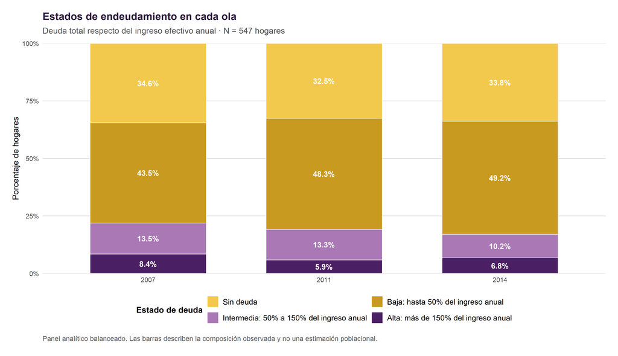

```r
figura_estados_ola <- ggplot2::ggplot(
  tabla_estados_ola,
  ggplot2::aes(
    x =
      factor(
        anio
      ),
    y =
      porcentaje,
    fill =
      estado_deuda
  )
) +
  ggplot2::geom_col(
    width = 0.66,
    color = "white",
    linewidth = 0.35
  ) +
  ggplot2::geom_text(
    ggplot2::aes(
      label =
        dplyr::if_else(
          porcentaje >= 5,
          paste0(
            round(
              porcentaje,
              1
            ),
            "%"
          ),
          ""
        )
    ),
    position =
      ggplot2::position_stack(
        vjust = 0.5
      ),
    color =
      "white",
    fontface =
      "bold",
    size =
      4
  ) +
  ggplot2::scale_fill_manual(
    values =
      paleta_deuda,
    labels =
      etiquetas_deuda_leyenda,
    drop =
      FALSE,
    guide =
      ggplot2::guide_legend(
        nrow = 2,
        byrow = TRUE
      )
  ) +
  ggplot2::scale_y_continuous(
    labels =
      scales::label_percent(
        scale = 1
      ),
    limits =
      c(
        0,
        100
      ),
    expand =
      ggplot2::expansion(
        mult = c(
          0,
          0
        )
      )
  ) +
  ggplot2::labs(
    title =
      "Estados de endeudamiento en cada ola",

    subtitle =
      paste0(
        "Deuda total respecto del ingreso efectivo anual · N = ",
        dplyr::n_distinct(
          base_analitica$panel_id
        ),
        " hogares"
      ),

    x =
      NULL,

    y =
      "Porcentaje de hogares",

    fill =
      "Estado de deuda",

    caption =
      paste(
        "Panel analítico balanceado.",
        "Las barras describen la composición observada y no una estimación poblacional."
      )
  ) +
  tema_taller() +
  ggplot2::theme(
    panel.grid.major.y =
      ggplot2::element_line(
        color = "grey88"
      )
  )

figura_estados_ola
```

# 21 Distribución continua de la razón deuda-ingreso

**Mostrar código**

```r
limite_visual_rdi <- stats::quantile(
  base_analitica$razon_deuda_ingreso[
    base_analitica$deuda_total > 0
  ],
  probs = 0.95,
  na.rm = TRUE,
  names = FALSE
)

base_rdi_figura <- base_analitica |>
  dplyr::filter(
    deuda_total > 0,
    razon_deuda_ingreso <=
      limite_visual_rdi
  )
```

# 22 Figura 2. Distribución de deuda sobre ingreso

**Mostrar código**

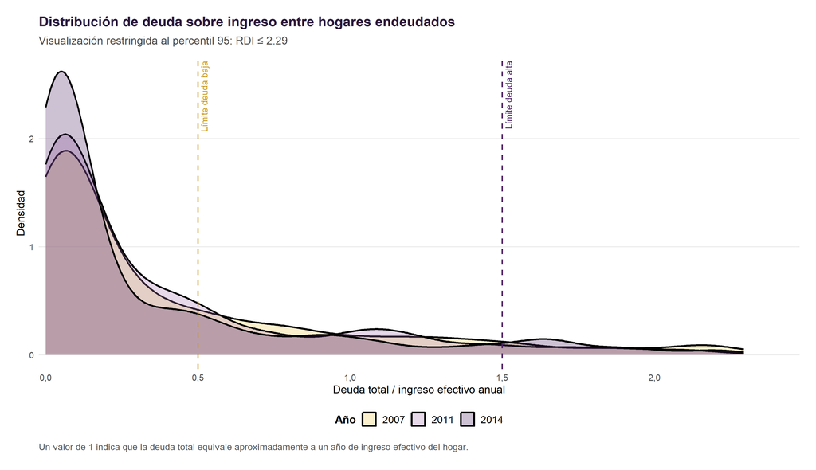

```r
figura_distribucion_rdi <- ggplot2::ggplot(
  base_rdi_figura,
  ggplot2::aes(
    x =
      razon_deuda_ingreso,
    fill =
      factor(
        anio
      )
  )
) +
  ggplot2::geom_density(
    alpha = 0.28,
    linewidth = 0.9
  ) +
  ggplot2::geom_vline(
    xintercept = limite_deuda_baja,
    linetype = "dashed",
    linewidth = 0.75,
    color = color_mostaza_oscuro
  ) +
  ggplot2::geom_vline(
    xintercept = limite_deuda_intermedia,
    linetype = "dashed",
    linewidth = 0.75,
    color = color_morado_oscuro
  ) +
  ggplot2::annotate(
    geom = "text",
    x = limite_deuda_baja,
    y = Inf,
    label = "Límite deuda baja",
    angle = 90,
    vjust = 1.4,
    hjust = 1.05,
    size = 3.5,
    color = color_mostaza_oscuro
  ) +
  ggplot2::annotate(
    geom = "text",
    x = limite_deuda_intermedia,
    y = Inf,
    label = "Límite deuda alta",
    angle = 90,
    vjust = 1.4,
    hjust = 1.05,
    size = 3.5,
    color = color_morado_oscuro
  ) +
  ggplot2::scale_fill_manual(
    values = c(
      "2007" = color_mostaza,
      "2011" = color_morado_claro,
      "2014" = color_morado_oscuro
    )
  ) +
  ggplot2::scale_x_continuous(
    labels =
      scales::label_number(
        accuracy = 0.1,
        decimal.mark = ","
      ),
    expand =
      ggplot2::expansion(
        mult = c(
          0.01,
          0.08
        )
      )
  ) +
  ggplot2::coord_cartesian(
    clip = "off"
  ) +
  ggplot2::labs(
    title =
      "Distribución de deuda sobre ingreso entre hogares endeudados",

    subtitle =
      paste0(
        "Visualización restringida al percentil 95: RDI ≤ ",
        round(
          limite_visual_rdi,
          2
        )
      ),

    x =
      "Deuda total / ingreso efectivo anual",

    y =
      "Densidad",

    fill =
      "Año",

    caption =
      paste(
        "Un valor de 1 indica que la deuda total equivale aproximadamente",
        "a un año de ingreso efectivo del hogar."
      )
  ) +
  tema_taller()

figura_distribucion_rdi
```

# 23 Base en formato ancho

**Mostrar código**

```r
base_wide <- base_analitica |>
  dplyr::select(
    panel_id,
    id,
    anio,
    estado_deuda,
    nivel_deuda_numerico,
    razon_deuda_ingreso
  ) |>
  tidyr::pivot_wider(
    names_from =
      anio,

    values_from =
      c(
        id,
        estado_deuda,
        nivel_deuda_numerico,
        razon_deuda_ingreso
      ),

    names_sep =
      "_"
  )
```

**Mostrar código**

```r
variables_estado_esperadas <- paste0(
  "estado_deuda_",
  anios_analisis
)

if (
  !all(
    variables_estado_esperadas %in%
      names(
        base_wide
      )
  )
) {

  stop(
    paste0(
      "No fue posible crear los estados para las tres olas. ",
      "Columnas esperadas: ",
      paste(
        variables_estado_esperadas,
        collapse = ", "
      )
    )
  )
}
```

# 24 Matrices de transición

## 24.1 Función de transición

**Mostrar código**

```r
calcular_transicion <- function(
    datos,
    anio_inicial,
    anio_final
) {

  variable_inicial <- paste0(
    "estado_deuda_",
    anio_inicial
  )

  variable_final <- paste0(
    "estado_deuda_",
    anio_final
  )

  datos |>
    dplyr::count(
      estado_inicial =
        .data[[
          variable_inicial
        ]],

      estado_final =
        .data[[
          variable_final
        ]],

      name =
        "n",

      .drop =
        FALSE
    ) |>
    dplyr::group_by(
      estado_inicial
    ) |>
    dplyr::mutate(
      total_estado_inicial =
        sum(
          n
        ),

      porcentaje_fila =
        100 *
          n /
          total_estado_inicial
    ) |>
    dplyr::ungroup() |>
    dplyr::mutate(
      periodo =
        paste0(
          anio_inicial,
          "–",
          anio_final
        ),
      .before = 1
    )
}
```

**Mostrar código**

```r
tabla_transicion_2007_2011 <- calcular_transicion(
  datos = base_wide,
  anio_inicial = 2007,
  anio_final = 2011
)

tabla_transicion_2011_2014 <- calcular_transicion(
  datos = base_wide,
  anio_inicial = 2011,
  anio_final = 2014
)

tabla_transicion_2007_2014 <- calcular_transicion(
  datos = base_wide,
  anio_inicial = 2007,
  anio_final = 2014
)
```

## 24.2 Matriz 2007–2011

**Mostrar código**

```r
knitr::kable(
  tabla_transicion_2007_2011 |>
    dplyr::mutate(
      porcentaje_fila =
        round(
          porcentaje_fila,
          1
        )
    ),
  caption = "Transiciones entre estados de deuda, 2007–2011"
)
```

Transiciones entre estados de deuda, 2007–2011

| periodo | estado_inicial | estado_final | n | total_estado_inicial | porcentaje_fila |
| --- | --- | --- | --- | --- | --- |
| 2007–2011 | Sin deuda | Sin deuda | 99 | 189 | 52.4 |
| 2007–2011 | Sin deuda | Deuda baja | 79 | 189 | 41.8 |
| 2007–2011 | Sin deuda | Deuda intermedia | 7 | 189 | 3.7 |
| 2007–2011 | Sin deuda | Deuda alta | 4 | 189 | 2.1 |
| 2007–2011 | Deuda baja | Sin deuda | 63 | 238 | 26.5 |
| 2007–2011 | Deuda baja | Deuda baja | 141 | 238 | 59.2 |
| 2007–2011 | Deuda baja | Deuda intermedia | 22 | 238 | 9.2 |
| 2007–2011 | Deuda baja | Deuda alta | 12 | 238 | 5.0 |
| 2007–2011 | Deuda intermedia | Sin deuda | 10 | 74 | 13.5 |
| 2007–2011 | Deuda intermedia | Deuda baja | 31 | 74 | 41.9 |
| 2007–2011 | Deuda intermedia | Deuda intermedia | 27 | 74 | 36.5 |
| 2007–2011 | Deuda intermedia | Deuda alta | 6 | 74 | 8.1 |
| 2007–2011 | Deuda alta | Sin deuda | 6 | 46 | 13.0 |
| 2007–2011 | Deuda alta | Deuda baja | 13 | 46 | 28.3 |
| 2007–2011 | Deuda alta | Deuda intermedia | 17 | 46 | 37.0 |
| 2007–2011 | Deuda alta | Deuda alta | 10 | 46 | 21.7 |

## 24.3 Matriz 2011–2014

**Mostrar código**

```r
knitr::kable(
  tabla_transicion_2011_2014 |>
    dplyr::mutate(
      porcentaje_fila =
        round(
          porcentaje_fila,
          1
        )
    ),
  caption = "Transiciones entre estados de deuda, 2011–2014"
)
```

Transiciones entre estados de deuda, 2011–2014

| periodo | estado_inicial | estado_final | n | total_estado_inicial | porcentaje_fila |
| --- | --- | --- | --- | --- | --- |
| 2011–2014 | Sin deuda | Sin deuda | 91 | 178 | 51.1 |
| 2011–2014 | Sin deuda | Deuda baja | 76 | 178 | 42.7 |
| 2011–2014 | Sin deuda | Deuda intermedia | 9 | 178 | 5.1 |
| 2011–2014 | Sin deuda | Deuda alta | 2 | 178 | 1.1 |
| 2011–2014 | Deuda baja | Sin deuda | 78 | 264 | 29.5 |
| 2011–2014 | Deuda baja | Deuda baja | 149 | 264 | 56.4 |
| 2011–2014 | Deuda baja | Deuda intermedia | 21 | 264 | 8.0 |
| 2011–2014 | Deuda baja | Deuda alta | 16 | 264 | 6.1 |
| 2011–2014 | Deuda intermedia | Sin deuda | 10 | 73 | 13.7 |
| 2011–2014 | Deuda intermedia | Deuda baja | 37 | 73 | 50.7 |
| 2011–2014 | Deuda intermedia | Deuda intermedia | 17 | 73 | 23.3 |
| 2011–2014 | Deuda intermedia | Deuda alta | 9 | 73 | 12.3 |
| 2011–2014 | Deuda alta | Sin deuda | 6 | 32 | 18.8 |
| 2011–2014 | Deuda alta | Deuda baja | 7 | 32 | 21.9 |
| 2011–2014 | Deuda alta | Deuda intermedia | 9 | 32 | 28.1 |
| 2011–2014 | Deuda alta | Deuda alta | 10 | 32 | 31.2 |

## 24.4 Matriz 2007–2014

**Mostrar código**

```r
knitr::kable(
  tabla_transicion_2007_2014 |>
    dplyr::mutate(
      porcentaje_fila =
        round(
          porcentaje_fila,
          1
        )
    ),
  caption = "Transiciones entre estados de deuda, 2007–2014"
)
```

Transiciones entre estados de deuda, 2007–2014

| periodo | estado_inicial | estado_final | n | total_estado_inicial | porcentaje_fila |
| --- | --- | --- | --- | --- | --- |
| 2007–2014 | Sin deuda | Sin deuda | 105 | 189 | 55.6 |
| 2007–2014 | Sin deuda | Deuda baja | 66 | 189 | 34.9 |
| 2007–2014 | Sin deuda | Deuda intermedia | 10 | 189 | 5.3 |
| 2007–2014 | Sin deuda | Deuda alta | 8 | 189 | 4.2 |
| 2007–2014 | Deuda baja | Sin deuda | 63 | 238 | 26.5 |
| 2007–2014 | Deuda baja | Deuda baja | 142 | 238 | 59.7 |
| 2007–2014 | Deuda baja | Deuda intermedia | 19 | 238 | 8.0 |
| 2007–2014 | Deuda baja | Deuda alta | 14 | 238 | 5.9 |
| 2007–2014 | Deuda intermedia | Sin deuda | 10 | 74 | 13.5 |
| 2007–2014 | Deuda intermedia | Deuda baja | 44 | 74 | 59.5 |
| 2007–2014 | Deuda intermedia | Deuda intermedia | 15 | 74 | 20.3 |
| 2007–2014 | Deuda intermedia | Deuda alta | 5 | 74 | 6.8 |
| 2007–2014 | Deuda alta | Sin deuda | 7 | 46 | 15.2 |
| 2007–2014 | Deuda alta | Deuda baja | 17 | 46 | 37.0 |
| 2007–2014 | Deuda alta | Deuda intermedia | 12 | 46 | 26.1 |
| 2007–2014 | Deuda alta | Deuda alta | 10 | 46 | 21.7 |

# 25 Permanencia en el mismo estado

**Mostrar código**

```r
tabla_permanencia_general <- base_wide |>
  dplyr::summarise(
    hogares =
      dplyr::n(),

    porcentaje_mismo_estado_2007_2011 =
      100 *
        mean(
          estado_deuda_2007 ==
            estado_deuda_2011
        ),

    porcentaje_mismo_estado_2011_2014 =
      100 *
        mean(
          estado_deuda_2011 ==
            estado_deuda_2014
        ),

    porcentaje_mismo_estado_2007_2014 =
      100 *
        mean(
          estado_deuda_2007 ==
            estado_deuda_2014
        ),

    porcentaje_mismo_estado_tres_olas =
      100 *
        mean(
          estado_deuda_2007 ==
            estado_deuda_2011 &
          estado_deuda_2011 ==
            estado_deuda_2014
        )
  )
```

**Mostrar código**

```r
knitr::kable(
  tabla_permanencia_general,
  digits = 1,
  caption = "Permanencia general en los estados de endeudamiento"
)
```

Permanencia general en los estados de endeudamiento

| hogares | porcentaje_mismo_estado_2007_2011 | porcentaje_mismo_estado_2011_2014 | porcentaje_mismo_estado_2007_2014 | porcentaje_mismo_estado_tres_olas |
| --- | --- | --- | --- | --- |
| 547 | 50.6 | 48.8 | 49.7 | 30.5 |

# 26 Permanencia según estado inicial

**Mostrar código**

```r
tabla_permanencia_origen <- base_wide |>
  dplyr::mutate(
    mismo_estado_2014 =
      estado_deuda_2007 ==
        estado_deuda_2014
  ) |>
  dplyr::group_by(
    estado_inicial =
      estado_deuda_2007
  ) |>
  dplyr::summarise(
    hogares_iniciales =
      dplyr::n(),

    hogares_mismo_estado =
      sum(
        mismo_estado_2014
      ),

    porcentaje_mismo_estado =
      100 *
        mean(
          mismo_estado_2014
        ),

    .groups =
      "drop"
  ) |>
  dplyr::mutate(
    estado_inicial =
      factor(
        estado_inicial,
        levels = niveles_deuda,
        ordered = TRUE
      )
  )
```

# 27 Figura 3. Permanencia según estado inicial

**Mostrar código**

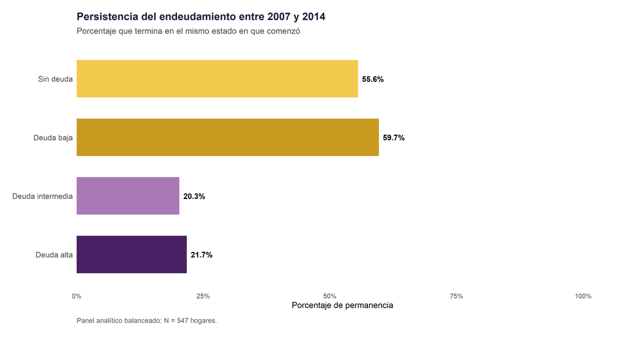

```r
figura_permanencia <- ggplot2::ggplot(
  tabla_permanencia_origen,
  ggplot2::aes(
    x =
      porcentaje_mismo_estado,

    y =
      forcats::fct_rev(
        estado_inicial
      ),

    fill =
      estado_inicial
  )
) +
  ggplot2::geom_col(
    width = 0.64
  ) +
  ggplot2::geom_text(
    ggplot2::aes(
      label =
        paste0(
          round(
            porcentaje_mismo_estado,
            1
          ),
          "%"
        )
    ),
    hjust =
      -0.18,
    size =
      4,
    fontface =
      "bold"
  ) +
  ggplot2::scale_fill_manual(
    values =
      paleta_deuda,
    drop =
      FALSE
  ) +
  ggplot2::scale_x_continuous(
    labels =
      scales::label_percent(
        scale = 1
      ),
    limits =
      c(
        0,
        100
      ),
    expand =
      ggplot2::expansion(
        mult = c(
          0,
          0.05
        )
      )
  ) +
  ggplot2::coord_cartesian(
    clip = "off"
  ) +
  ggplot2::labs(
    title =
      "Persistencia del endeudamiento entre 2007 y 2014",

    subtitle =
      "Porcentaje que termina en el mismo estado en que comenzó",

    x =
      "Porcentaje de permanencia",

    y =
      NULL,

    caption =
      paste0(
        "Panel analítico balanceado: N = ",
        nrow(
          base_wide
        ),
        " hogares."
      )
  ) +
  tema_taller() +
  ggplot2::theme(
    panel.grid.major.y =
      ggplot2::element_blank(),

    legend.position =
      "none",

    axis.text.y =
      ggplot2::element_text(
        size = 11
      )
  )

figura_permanencia
```

# 28 Dirección de los cambios

**Mostrar código**

```r
base_wide <- base_wide |>
  dplyr::mutate(
    diferencia_nivel =
      nivel_deuda_numerico_2014 -
        nivel_deuda_numerico_2007,

    direccion_cambio =
      dplyr::case_when(
        diferencia_nivel < 0 ~
          "Disminuyó",

        diferencia_nivel == 0 ~
          "Permaneció",

        diferencia_nivel > 0 ~
          "Aumentó",

        TRUE ~
          NA_character_
      ),

    direccion_cambio =
      factor(
        direccion_cambio,
        levels = niveles_direccion
      )
  )

tabla_direccion_cambio <- base_wide |>
  dplyr::count(
    direccion_cambio,
    name = "n",
    .drop = FALSE
  ) |>
  dplyr::mutate(
    porcentaje =
      100 *
        n /
        sum(
          n
        )
  )
```

**Mostrar código**

```r
knitr::kable(
  tabla_direccion_cambio |>
    dplyr::mutate(
      porcentaje =
        round(
          porcentaje,
          1
        )
    ),
  caption = "Dirección del cambio en el nivel de endeudamiento, 2007–2014"
)
```

Dirección del cambio en el nivel de endeudamiento, 2007–2014

| direccion_cambio | n | porcentaje |
| --- | --- | --- |
| Disminuyó | 153 | 28.0 |
| Permaneció | 272 | 49.7 |
| Aumentó | 122 | 22.3 |

# 29 Figura 4. Dirección del cambio

**Mostrar código**

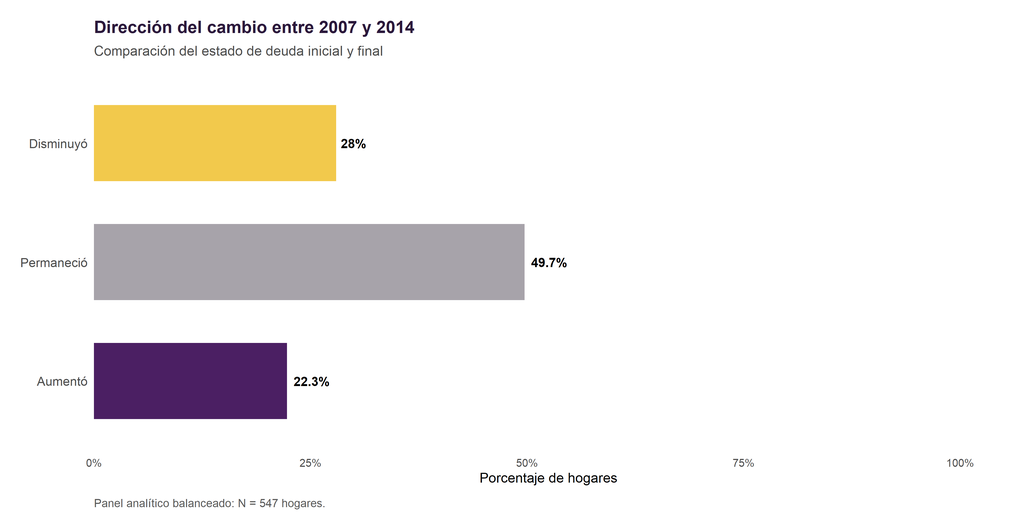

```r
figura_direccion <- ggplot2::ggplot(
  tabla_direccion_cambio,
  ggplot2::aes(
    x =
      porcentaje,

    y =
      forcats::fct_rev(
        direccion_cambio
      ),

    fill =
      direccion_cambio
  )
) +
  ggplot2::geom_col(
    width = 0.64
  ) +
  ggplot2::geom_text(
    ggplot2::aes(
      label =
        paste0(
          round(
            porcentaje,
            1
          ),
          "%"
        )
    ),
    hjust =
      -0.18,
    size =
      4,
    fontface =
      "bold"
  ) +
  ggplot2::scale_fill_manual(
    values =
      paleta_direccion_composicion,
    drop =
      FALSE
  ) +
  ggplot2::scale_x_continuous(
    labels =
      scales::label_percent(
        scale = 1
      ),
    limits =
      c(
        0,
        100
      ),
    expand =
      ggplot2::expansion(
        mult = c(
          0,
          0.05
        )
      )
  ) +
  ggplot2::coord_cartesian(
    clip = "off"
  ) +
  ggplot2::labs(
    title =
      "Dirección del cambio entre 2007 y 2014",

    subtitle =
      "Comparación del estado de deuda inicial y final",

    x =
      "Porcentaje de hogares",

    y =
      NULL,

    caption =
      paste0(
        "Panel analítico balanceado: N = ",
        nrow(
          base_wide
        ),
        " hogares."
      )
  ) +
  tema_taller() +
  ggplot2::theme(
    panel.grid.major.y =
      ggplot2::element_blank(),

    legend.position =
      "none",

    axis.text.y =
      ggplot2::element_text(
        size = 11
      )
  )

figura_direccion
```

# 30 Género, situación de pareja y transiciones

La comparación general por género de la persona de referencia produce distribuciones muy similares. Para observar configuraciones más específicas se incorpora también la situación de pareja de la persona de referencia observada en 2014.

Esta clasificación se mide al final del periodo. Por tanto, no debe interpretarse como una condición inicial ni como una causa de la trayectoria.

## 30.1 Lectura de la base EFH 2014

**Mostrar código**

```r
efh_2014_original <- haven::read_dta(
  ruta_efh_2014
) |>
  tibble::as_tibble()

variables_2014_requeridas <- c(
  "id",
  "genero_pr",
  "est_civil_pr"
)

variables_2014_faltantes <- setdiff(
  variables_2014_requeridas,
  names(
    efh_2014_original
  )
)

if (
  length(
    variables_2014_faltantes
  ) > 0
) {

  stop(
    paste0(
      "La base EFH 2014 no contiene las siguientes variables:\n",
      paste(
        variables_2014_faltantes,
        collapse = ", "
      )
    )
  )
}
```

## 30.2 Preparación de la persona de referencia

**Mostrar código**

```r
base_persona_referencia_2014 <- efh_2014_original |>
  dplyr::transmute(
    id =
      as.character(
        id
      ),

    genero_pr_original =
      convertir_etiquetado_a_texto(
        genero_pr
      ),

    estado_civil_pr_original =
      convertir_etiquetado_a_texto(
        est_civil_pr
      )
  ) |>
  dplyr::mutate(
    genero_pr_normalizado =
      normalizar_texto(
        genero_pr_original
      ),

    estado_civil_pr_normalizado =
      normalizar_texto(
        estado_civil_pr_original
      )
  ) |>
  dplyr::group_by(
    id
  ) |>
  dplyr::summarise(
    genero_pr_original =
      primer_valor_valido(
        genero_pr_original
      ),

    estado_civil_pr_original =
      primer_valor_valido(
        estado_civil_pr_original
      ),

    genero_pr_normalizado =
      primer_valor_valido(
        genero_pr_normalizado
      ),

    estado_civil_pr_normalizado =
      primer_valor_valido(
        estado_civil_pr_normalizado
      ),

    .groups =
      "drop"
  ) |>
  dplyr::mutate(
    genero_persona_referencia =
      dplyr::case_when(
        stringr::str_detect(
          genero_pr_normalizado,
          "^mujer$|femen"
        ) ~
          "Mujer",

        stringr::str_detect(
          genero_pr_normalizado,
          "^hombre$|mascul"
        ) ~
          "Hombre",

        TRUE ~
          NA_character_
      ),

    situacion_pareja =
      dplyr::case_when(
        stringr::str_detect(
          estado_civil_pr_normalizado,
          "casad|conviv"
        ) ~
          "Con pareja",

        !is.na(
          estado_civil_pr_normalizado
        ) &
          estado_civil_pr_normalizado != "" ~
          "Sin pareja",

        TRUE ~
          NA_character_
      ),

    grupo_genero_pareja =
      dplyr::case_when(
        genero_persona_referencia == "Mujer" &
          situacion_pareja == "Sin pareja" ~
          "Mujer sin pareja",

        genero_persona_referencia == "Mujer" &
          situacion_pareja == "Con pareja" ~
          "Mujer con pareja",

        genero_persona_referencia == "Hombre" &
          situacion_pareja == "Sin pareja" ~
          "Hombre sin pareja",

        genero_persona_referencia == "Hombre" &
          situacion_pareja == "Con pareja" ~
          "Hombre con pareja",

        TRUE ~
          NA_character_
      ),

    grupo_genero_pareja =
      factor(
        grupo_genero_pareja,
        levels = c(
          "Mujer sin pareja",
          "Mujer con pareja",
          "Hombre sin pareja",
          "Hombre con pareja"
        )
      )
  )
```

## 30.3 Unión con el panel analítico

**Mostrar código**

```r
base_wide <- base_wide |>
  dplyr::left_join(
    base_persona_referencia_2014 |>
      dplyr::select(
        id,
        genero_persona_referencia,
        situacion_pareja,
        grupo_genero_pareja
      ),
    by = c(
      "id_2014" = "id"
    )
  )
```

## 30.4 Auditoría de la unión

**Mostrar código**

```r
tabla_union_persona_referencia <- tibble::tibble(
  indicador = c(
    "Hogares del panel analítico",
    "Hogares con ID válido en 2014",
    "Hogares con género de referencia válido",
    "Hogares con situación de pareja válida",
    "Hogares con clasificación conjunta válida",
    "Porcentaje con clasificación conjunta válida"
  ),

  valor = c(
    nrow(
      base_wide
    ),

    sum(
      !is.na(
        base_wide$id_2014
      ) &
        base_wide$id_2014 != ""
    ),

    sum(
      !is.na(
        base_wide$genero_persona_referencia
      )
    ),

    sum(
      !is.na(
        base_wide$situacion_pareja
      )
    ),

    sum(
      !is.na(
        base_wide$grupo_genero_pareja
      )
    ),

    100 *
      mean(
        !is.na(
          base_wide$grupo_genero_pareja
        )
      )
  )
)

knitr::kable(
  tabla_union_persona_referencia |>
    dplyr::mutate(
      valor =
        round(
          valor,
          1
        )
    ),
  caption = "Cobertura de las variables de persona de referencia"
)
```

Cobertura de las variables de persona de referencia

| indicador | valor |
| --- | --- |
| Hogares del panel analítico | 547 |
| Hogares con ID válido en 2014 | 547 |
| Hogares con género de referencia válido | 547 |
| Hogares con situación de pareja válida | 547 |
| Hogares con clasificación conjunta válida | 547 |
| Porcentaje con clasificación conjunta válida | 100 |

## 30.5 Dirección del cambio según composición

**Mostrar código**

```r
tabla_direccion_genero_pareja <- base_wide |>
  dplyr::filter(
    !is.na(
      grupo_genero_pareja
    ),
    !is.na(
      direccion_cambio
    )
  ) |>
  dplyr::count(
    grupo_genero_pareja,
    direccion_cambio,
    name = "n",
    .drop = FALSE
  ) |>
  dplyr::group_by(
    grupo_genero_pareja
  ) |>
  dplyr::mutate(
    n_grupo =
      sum(
        n
      ),

    porcentaje =
      100 *
        n /
        n_grupo
  ) |>
  dplyr::ungroup()
```

**Mostrar código**

```r
knitr::kable(
  tabla_direccion_genero_pareja |>
    dplyr::mutate(
      porcentaje =
        round(
          porcentaje,
          1
        )
    ),
  caption = paste(
    "Dirección del cambio según género y situación de pareja",
    "de la persona de referencia en 2014"
  )
)
```

Dirección del cambio según género y situación de pareja de la persona de referencia en 2014

| grupo_genero_pareja | direccion_cambio | n | n_grupo | porcentaje |
| --- | --- | --- | --- | --- |
| Mujer sin pareja | Disminuyó | 36 | 123 | 29.3 |
| Mujer sin pareja | Permaneció | 58 | 123 | 47.2 |
| Mujer sin pareja | Aumentó | 29 | 123 | 23.6 |
| Mujer con pareja | Disminuyó | 16 | 60 | 26.7 |
| Mujer con pareja | Permaneció | 35 | 60 | 58.3 |
| Mujer con pareja | Aumentó | 9 | 60 | 15.0 |
| Hombre sin pareja | Disminuyó | 20 | 76 | 26.3 |
| Hombre sin pareja | Permaneció | 37 | 76 | 48.7 |
| Hombre sin pareja | Aumentó | 19 | 76 | 25.0 |
| Hombre con pareja | Disminuyó | 81 | 288 | 28.1 |
| Hombre con pareja | Permaneció | 142 | 288 | 49.3 |
| Hombre con pareja | Aumentó | 65 | 288 | 22.6 |

# 31 Figura 5. Transiciones según género y situación de pareja

**Mostrar código**

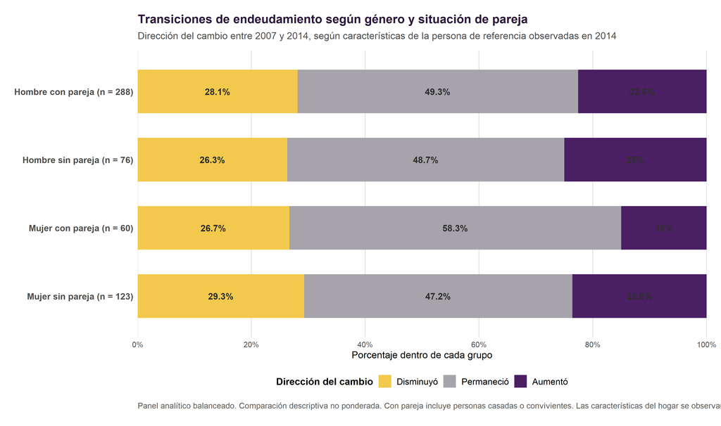

```r
etiquetas_grupos_composicion <- tabla_direccion_genero_pareja |>
  dplyr::distinct(
    grupo_genero_pareja,
    n_grupo
  ) |>
  dplyr::mutate(
    etiqueta =
      paste0(
        as.character(
          grupo_genero_pareja
        ),
        " (n = ",
        n_grupo,
        ")"
      )
  )

vector_etiquetas_grupos <- stats::setNames(
  etiquetas_grupos_composicion$etiqueta,
  as.character(
    etiquetas_grupos_composicion$grupo_genero_pareja
  )
)

figura_direccion_genero_pareja <- ggplot2::ggplot(
  tabla_direccion_genero_pareja,
  ggplot2::aes(
    x =
      porcentaje,

    y =
      grupo_genero_pareja,

    fill =
      direccion_cambio
  )
) +
  ggplot2::geom_col(
    width = 0.64,
    position =
      ggplot2::position_stack(
        reverse = TRUE
      )
  ) +
  ggplot2::geom_text(
    ggplot2::aes(
      label =
        dplyr::if_else(
          porcentaje >= 6,
          paste0(
            round(
              porcentaje,
              1
            ),
            "%"
          ),
          ""
        )
    ),
    position =
      ggplot2::position_stack(
        vjust = 0.5,
        reverse = TRUE
      ),
    color =
      color_texto,
    fontface =
      "bold",
    size =
      4
  ) +
  ggplot2::scale_fill_manual(
    values =
      paleta_direccion_composicion,

    breaks =
      niveles_direccion,

    limits =
      niveles_direccion,

    labels =
      niveles_direccion,

    drop =
      FALSE,

    guide =
      ggplot2::guide_legend(
        nrow = 1,
        byrow = TRUE
      )
  ) +
  ggplot2::scale_y_discrete(
    labels =
      vector_etiquetas_grupos
  ) +
  ggplot2::scale_x_continuous(
    labels =
      scales::label_percent(
        scale = 1,
        accuracy = 1
      ),
    limits =
      c(
        0,
        100
      ),
    breaks =
      seq(
        0,
        100,
        20
      ),
    expand =
      ggplot2::expansion(
        mult = c(
          0,
          0
        )
      )
  ) +
  ggplot2::labs(
    title =
      "Transiciones de endeudamiento según género y situación de pareja",

    subtitle =
      paste(
        "Dirección del cambio entre 2007 y 2014, según características",
        "de la persona de referencia observadas en 2014"
      ),

    x =
      "Porcentaje dentro de cada grupo",

    y =
      NULL,

    fill =
      "Dirección del cambio",

    caption =
      paste(
        "Panel analítico balanceado. Comparación descriptiva no ponderada.",
        "Con pareja incluye personas casadas o convivientes.",
        "Las características del hogar se observan al final del periodo."
      )
  ) +
  tema_taller(
    tamano_base = 12
  ) +
  ggplot2::theme(
    panel.grid.major.y =
      ggplot2::element_blank(),

    panel.grid.major.x =
      ggplot2::element_line(
        color = "grey88"
      ),

    axis.text.y =
      ggplot2::element_text(
        face = "bold",
        size = 11
      ),

    legend.position =
      "bottom"
  )

figura_direccion_genero_pareja
```

## 31.1 Lectura descriptiva

La comparación general por género de la persona de referencia muestra pocas diferencias. Al incorporar la situación de pareja aparece mayor heterogeneidad entre las mujeres.

Los hogares con una persona de referencia mujer sin pareja presentan una proporción mayor de aumento del nivel relativo de deuda que aquellos con una mujer con pareja. Entre los hombres, las diferencias según situación de pareja son considerablemente menores.

La comparación es descriptiva. La clasificación del hogar se observa en 2014 y no permite atribuir causalmente la trayectoria a su composición.

# 32 Trayectorias completas

**Mostrar código**

```r
tabla_trayectorias <- base_wide |>
  dplyr::count(
    estado_deuda_2007,
    estado_deuda_2011,
    estado_deuda_2014,
    name = "n"
  ) |>
  dplyr::mutate(
    porcentaje =
      100 *
        n /
        sum(
          n
        ),

    trayectoria =
      paste(
        estado_deuda_2007,
        estado_deuda_2011,
        estado_deuda_2014,
        sep = " → "
      )
  ) |>
  dplyr::arrange(
    dplyr::desc(
      n
    )
  )
```

**Mostrar código**

```r
knitr::kable(
  tabla_trayectorias |>
    dplyr::slice_head(
      n = 15
    ) |>
    dplyr::mutate(
      porcentaje =
        round(
          porcentaje,
          1
        )
    ),
  caption = "Quince trayectorias de endeudamiento más frecuentes"
)
```

Quince trayectorias de endeudamiento más frecuentes

| estado_deuda_2007 | estado_deuda_2011 | estado_deuda_2014 | n | porcentaje | trayectoria |
| --- | --- | --- | --- | --- | --- |
| Deuda baja | Deuda baja | Deuda baja | 89 | 16.3 | Deuda baja → Deuda baja → Deuda baja |
| Sin deuda | Sin deuda | Sin deuda | 67 | 12.2 | Sin deuda → Sin deuda → Sin deuda |
| Deuda baja | Sin deuda | Deuda baja | 39 | 7.1 | Deuda baja → Sin deuda → Deuda baja |
| Sin deuda | Deuda baja | Sin deuda | 36 | 6.6 | Sin deuda → Deuda baja → Sin deuda |
| Sin deuda | Deuda baja | Deuda baja | 36 | 6.6 | Sin deuda → Deuda baja → Deuda baja |
| Deuda baja | Deuda baja | Sin deuda | 34 | 6.2 | Deuda baja → Deuda baja → Sin deuda |
| Sin deuda | Sin deuda | Deuda baja | 28 | 5.1 | Sin deuda → Sin deuda → Deuda baja |
| Deuda baja | Sin deuda | Sin deuda | 19 | 3.5 | Deuda baja → Sin deuda → Sin deuda |
| Deuda intermedia | Deuda baja | Deuda baja | 18 | 3.3 | Deuda intermedia → Deuda baja → Deuda baja |
| Deuda intermedia | Deuda intermedia | Deuda baja | 18 | 3.3 | Deuda intermedia → Deuda intermedia → Deuda baja |
| Deuda baja | Deuda baja | Deuda intermedia | 11 | 2.0 | Deuda baja → Deuda baja → Deuda intermedia |
| Deuda baja | Deuda intermedia | Deuda baja | 10 | 1.8 | Deuda baja → Deuda intermedia → Deuda baja |
| Deuda baja | Deuda baja | Deuda alta | 7 | 1.3 | Deuda baja → Deuda baja → Deuda alta |
| Deuda intermedia | Sin deuda | Deuda baja | 7 | 1.3 | Deuda intermedia → Sin deuda → Deuda baja |
| Deuda intermedia | Deuda intermedia | Deuda intermedia | 7 | 1.3 | Deuda intermedia → Deuda intermedia → Deuda intermedia |

# 33 Preparación del gráfico alluvial

**Mostrar código**

```r
trayectorias_alluvial <- tabla_trayectorias |>
  dplyr::mutate(
    trayectoria_id =
      trayectoria,

    destino_2014 =
      factor(
        estado_deuda_2014,
        levels = niveles_deuda,
        ordered = TRUE
      )
  )
```

**Mostrar código**

```r
trayectorias_long <- trayectorias_alluvial |>
  dplyr::select(
    trayectoria_id,
    n,
    destino_2014,
    `2007` =
      estado_deuda_2007,
    `2011` =
      estado_deuda_2011,
    `2014` =
      estado_deuda_2014
  ) |>
  tidyr::pivot_longer(
    cols = c(
      `2007`,
      `2011`,
      `2014`
    ),
    names_to = "ola",
    values_to = "estado_deuda"
  ) |>
  dplyr::mutate(
    ola =
      factor(
        ola,
        levels = c(
          "2007",
          "2011",
          "2014"
        )
      ),

    estado_deuda =
      factor(
        estado_deuda,
        levels = niveles_deuda,
        ordered = TRUE
      )
  )
```

# 34 Figura 6. Trayectorias alluviales

**Mostrar código**

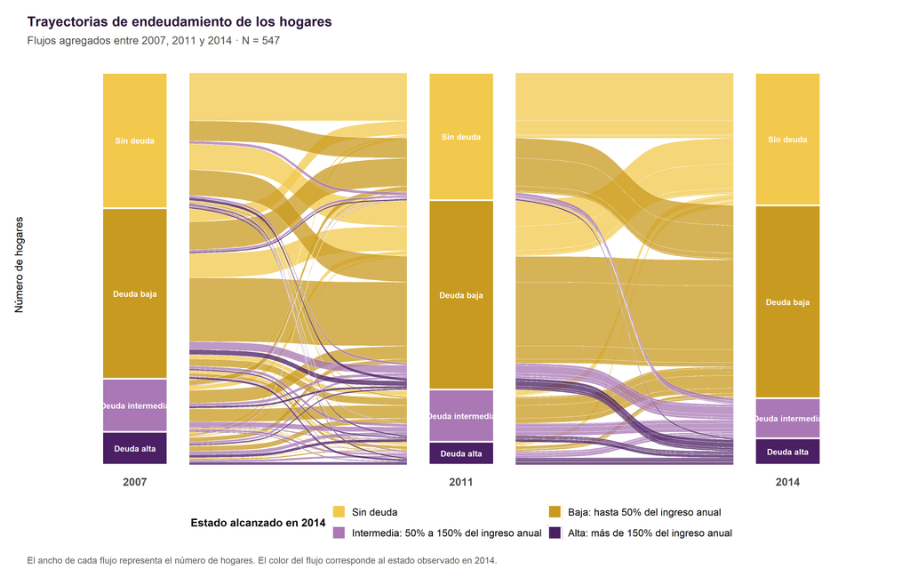

```r
figura_alluvial <- ggplot2::ggplot(
  trayectorias_long,
  ggplot2::aes(
    x =
      ola,

    stratum =
      estado_deuda,

    alluvium =
      trayectoria_id,

    y =
      n
  )
) +
  ggalluvial::geom_flow(
    ggplot2::aes(
      fill =
        destino_2014
    ),
    stat =
      "alluvium",
    alpha =
      0.76,
    color =
      "white",
    linewidth =
      0.18,
    knot.pos =
      0.42
  ) +
  ggalluvial::geom_stratum(
    ggplot2::aes(
      fill =
        estado_deuda
    ),
    color =
      "white",
    linewidth =
      0.9,
    width =
      0.20
  ) +
  ggplot2::geom_text(
    stat =
      "stratum",
    ggplot2::aes(
      label =
        after_stat(
          stratum
        )
    ),
    color =
      "white",
    fontface =
      "bold",
    size =
      3.2,
    lineheight =
      0.9
  ) +
  ggplot2::scale_fill_manual(
    values =
      paleta_deuda,
    labels =
      etiquetas_deuda_leyenda,
    drop =
      FALSE,
    guide =
      ggplot2::guide_legend(
        nrow = 2,
        byrow = TRUE
      )
  ) +
  ggplot2::scale_x_discrete(
    expand = c(
      0.11,
      0.11
    )
  ) +
  ggplot2::scale_y_continuous(
    expand =
      ggplot2::expansion(
        mult = c(
          0.02,
          0.04
        )
      )
  ) +
  ggplot2::coord_cartesian(
    clip = "off"
  ) +
  ggplot2::labs(
    title =
      "Trayectorias de endeudamiento de los hogares",

    subtitle =
      paste0(
        "Flujos agregados entre 2007, 2011 y 2014 · N = ",
        nrow(
          base_wide
        )
      ),

    x =
      NULL,

    y =
      "Número de hogares",

    fill =
      "Estado alcanzado en 2014",

    caption =
      paste(
        "El ancho de cada flujo representa el número de hogares.",
        "El color del flujo corresponde al estado observado en 2014."
      )
  ) +
  tema_taller(
    tamano_base = 12
  ) +
  ggplot2::theme(
    panel.grid =
      ggplot2::element_blank(),

    axis.text.x =
      ggplot2::element_text(
        face = "bold",
        size = 12
      ),

    axis.text.y =
      ggplot2::element_blank(),

    axis.ticks.y =
      ggplot2::element_blank(),

    legend.position =
      "bottom",

    plot.margin =
      ggplot2::margin(
        t = 18,
        r = 16,
        b = 22,
        l = 16
      )
  )

figura_alluvial
```

# 35 Probabilidad de terminar en deuda alta

**Mostrar código**

```r
tabla_riesgo_final <- base_wide |>
  dplyr::group_by(
    estado_inicial =
      estado_deuda_2007
  ) |>
  dplyr::summarise(
    hogares_iniciales =
      dplyr::n(),

    hogares_deuda_alta_2014 =
      sum(
        estado_deuda_2014 ==
          "Deuda alta"
      ),

    porcentaje_deuda_alta_2014 =
      100 *
        mean(
          estado_deuda_2014 ==
            "Deuda alta"
        ),

    hogares_sin_deuda_2014 =
      sum(
        estado_deuda_2014 ==
          "Sin deuda"
      ),

    porcentaje_sin_deuda_2014 =
      100 *
        mean(
          estado_deuda_2014 ==
            "Sin deuda"
        ),

    .groups =
      "drop"
  ) |>
  dplyr::mutate(
    estado_inicial =
      factor(
        estado_inicial,
        levels = niveles_deuda,
        ordered = TRUE
      )
  )
```

**Mostrar código**

```r
knitr::kable(
  tabla_riesgo_final |>
    dplyr::mutate(
      porcentaje_deuda_alta_2014 =
        round(
          porcentaje_deuda_alta_2014,
          1
        ),

      porcentaje_sin_deuda_2014 =
        round(
          porcentaje_sin_deuda_2014,
          1
        )
    ),
  caption = "Resultados en 2014 según el estado de endeudamiento en 2007"
)
```

Resultados en 2014 según el estado de endeudamiento en 2007

| estado_inicial | hogares_iniciales | hogares_deuda_alta_2014 | porcentaje_deuda_alta_2014 | hogares_sin_deuda_2014 | porcentaje_sin_deuda_2014 |
| --- | --- | --- | --- | --- | --- |
| Sin deuda | 189 | 8 | 4.2 | 105 | 55.6 |
| Deuda baja | 238 | 14 | 5.9 | 63 | 26.5 |
| Deuda intermedia | 74 | 5 | 6.8 | 10 | 13.5 |
| Deuda alta | 46 | 10 | 21.7 | 7 | 15.2 |

# 36 Figura 7. Deuda alta en 2014 según estado inicial

**Mostrar código**

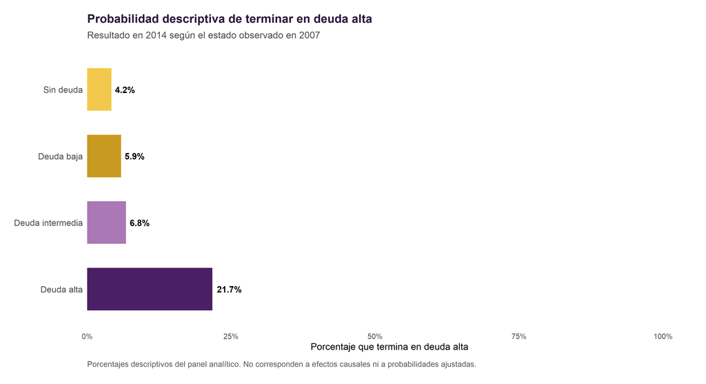

```r
figura_riesgo_final <- ggplot2::ggplot(
  tabla_riesgo_final,
  ggplot2::aes(
    x =
      porcentaje_deuda_alta_2014,

    y =
      forcats::fct_rev(
        estado_inicial
      ),

    fill =
      estado_inicial
  )
) +
  ggplot2::geom_col(
    width = 0.64
  ) +
  ggplot2::geom_text(
    ggplot2::aes(
      label =
        paste0(
          round(
            porcentaje_deuda_alta_2014,
            1
          ),
          "%"
        )
    ),
    hjust =
      -0.18,
    size =
      4,
    fontface =
      "bold"
  ) +
  ggplot2::scale_fill_manual(
    values =
      paleta_deuda,
    drop =
      FALSE
  ) +
  ggplot2::scale_x_continuous(
    labels =
      scales::label_percent(
        scale = 1
      ),
    limits =
      c(
        0,
        100
      ),
    expand =
      ggplot2::expansion(
        mult = c(
          0,
          0.05
        )
      )
  ) +
  ggplot2::coord_cartesian(
    clip = "off"
  ) +
  ggplot2::labs(
    title =
      "Probabilidad descriptiva de terminar en deuda alta",

    subtitle =
      "Resultado en 2014 según el estado observado en 2007",

    x =
      "Porcentaje que termina en deuda alta",

    y =
      NULL,

    caption =
      paste(
        "Porcentajes descriptivos del panel analítico.",
        "No corresponden a efectos causales ni a probabilidades ajustadas."
      )
  ) +
  tema_taller() +
  ggplot2::theme(
    panel.grid.major.y =
      ggplot2::element_blank(),

    legend.position =
      "none",

    axis.text.y =
      ggplot2::element_text(
        size = 11
      )
  )

figura_riesgo_final
```

# 37 Comparación de ponderaciones transversales

**Mostrar código**

```r
tabla_estados_ponderada <- base_analitica |>
  dplyr::group_by(
    anio,
    estado_deuda
  ) |>
  dplyr::summarise(
    frecuencia_ponderada =
      sum(
        ponderador,
        na.rm = TRUE
      ),
    .groups =
      "drop"
  ) |>
  dplyr::group_by(
    anio
  ) |>
  dplyr::mutate(
    porcentaje_ponderado =
      100 *
        frecuencia_ponderada /
        sum(
          frecuencia_ponderada
        )
  ) |>
  dplyr::ungroup()
```

**Mostrar código**

```r
tabla_comparacion_ponderacion <- tabla_estados_ola |>
  dplyr::select(
    anio,
    estado_deuda,
    porcentaje_no_ponderado =
      porcentaje
  ) |>
  dplyr::left_join(
    tabla_estados_ponderada |>
      dplyr::select(
        anio,
        estado_deuda,
        porcentaje_ponderado
      ),
    by = c(
      "anio",
      "estado_deuda"
    )
  )
```

**Mostrar código**

```r
knitr::kable(
  tabla_comparacion_ponderacion |>
    dplyr::mutate(
      porcentaje_no_ponderado =
        round(
          porcentaje_no_ponderado,
          1
        ),

      porcentaje_ponderado =
        round(
          porcentaje_ponderado,
          1
        )
    ),
  caption = "Distribución no ponderada y ponderada transversalmente"
)
```

Distribución no ponderada y ponderada transversalmente

| anio | estado_deuda | porcentaje_no_ponderado | porcentaje_ponderado |
| --- | --- | --- | --- |
| 2007 | Sin deuda | 34.6 | 37.3 |
| 2007 | Deuda baja | 43.5 | 43.3 |
| 2007 | Deuda intermedia | 13.5 | 12.6 |
| 2007 | Deuda alta | 8.4 | 6.7 |
| 2011 | Sin deuda | 32.5 | 34.2 |
| 2011 | Deuda baja | 48.3 | 46.6 |
| 2011 | Deuda intermedia | 13.3 | 13.0 |
| 2011 | Deuda alta | 5.9 | 6.2 |
| 2014 | Sin deuda | 33.8 | 26.6 |
| 2014 | Deuda baja | 49.2 | 61.5 |
| 2014 | Deuda intermedia | 10.2 | 9.2 |
| 2014 | Deuda alta | 6.8 | 2.7 |

# 38 Exportación de figuras

**Mostrar código**

```r
especificaciones_figuras <- tibble::tribble(
  ~nombre, ~ancho, ~alto,
  "07_01_estados_deuda_por_ola", 12.5, 7.2,
  "07_02_distribucion_rdi", 12.5, 7.2,
  "07_03_permanencia_por_origen", 12.5, 6.8,
  "07_04_direccion_cambio", 12.5, 6.5,
  "07_05_direccion_genero_pareja_2014", 12.5, 7.4,
  "07_06_trayectorias_alluvial", 14.0, 9.0,
  "07_07_deuda_alta_segun_origen", 12.5, 6.8
)

figuras_exportar <- list(
  "07_01_estados_deuda_por_ola" =
    figura_estados_ola,

  "07_02_distribucion_rdi" =
    figura_distribucion_rdi,

  "07_03_permanencia_por_origen" =
    figura_permanencia,

  "07_04_direccion_cambio" =
    figura_direccion,

  "07_05_direccion_genero_pareja_2014" =
    figura_direccion_genero_pareja,

  "07_06_trayectorias_alluvial" =
    figura_alluvial,

  "07_07_deuda_alta_segun_origen" =
    figura_riesgo_final
)
```

**Mostrar código**

```r
for (
  nombre_figura in
  names(
    figuras_exportar
  )
) {

  especificacion <- especificaciones_figuras |>
    dplyr::filter(
      nombre ==
        nombre_figura
    )

  ancho_figura <- especificacion$ancho[[1]]

  alto_figura <- especificacion$alto[[1]]

  ggplot2::ggsave(
    filename = file.path(
      ruta_figuras,
      paste0(
        nombre_figura,
        ".png"
      )
    ),
    plot =
      figuras_exportar[[
        nombre_figura
      ]],
    width =
      ancho_figura,
    height =
      alto_figura,
    units =
      "in",
    dpi =
      320,
    bg =
      "white",
    limitsize =
      FALSE
  )

  ggplot2::ggsave(
    filename = file.path(
      ruta_figuras,
      paste0(
        nombre_figura,
        ".svg"
      )
    ),
    plot =
      figuras_exportar[[
        nombre_figura
      ]],
    width =
      ancho_figura,
    height =
      alto_figura,
    units =
      "in",
    bg =
      "white",
    limitsize =
      FALSE
  )
}
```

# 39 Exportación de tablas CSV

**Mostrar código**

```r
tablas_csv <- list(
  "07_01_cobertura.csv" =
    tabla_cobertura,

  "07_02_muestra_analitica.csv" =
    tabla_muestra,

  "07_03_resumen_rdi.csv" =
    tabla_resumen_rdi,

  "07_04_estados_por_ola.csv" =
    tabla_estados_ola,

  "07_05_transicion_2007_2011.csv" =
    tabla_transicion_2007_2011,

  "07_06_transicion_2011_2014.csv" =
    tabla_transicion_2011_2014,

  "07_07_transicion_2007_2014.csv" =
    tabla_transicion_2007_2014,

  "07_08_permanencia_general.csv" =
    tabla_permanencia_general,

  "07_09_permanencia_origen.csv" =
    tabla_permanencia_origen,

  "07_10_direccion_cambio.csv" =
    tabla_direccion_cambio,

  "07_11_trayectorias.csv" =
    tabla_trayectorias,

  "07_12_resultado_final_segun_origen.csv" =
    tabla_riesgo_final,

  "07_13_comparacion_ponderacion.csv" =
    tabla_comparacion_ponderacion,

  "07_14_id_panel_por_anio.csv" =
    tabla_id_panel,

  "07_15_union_persona_referencia.csv" =
    tabla_union_persona_referencia,

  "07_16_direccion_genero_pareja.csv" =
    tabla_direccion_genero_pareja
)
```

**Mostrar código**

```r
purrr::iwalk(
  tablas_csv,
  function(
      tabla,
      nombre_archivo
  ) {

    readr::write_csv(
      hacer_exportable(
        tabla
      ),
      file.path(
        ruta_tablas,
        nombre_archivo
      ),
      na = ""
    )
  }
)
```

# 40 Libro Excel consolidado

**Mostrar código**

```r
archivo_excel <- file.path(
  ruta_tablas,
  "07_transiciones_deuda_ingreso.xlsx"
)

tablas_excel <- list(
  "Cobertura" =
    tabla_cobertura,

  "Muestra analítica" =
    tabla_muestra,

  "Resumen RDI" =
    tabla_resumen_rdi,

  "Estados por ola" =
    tabla_estados_ola,

  "Transición 2007 2011" =
    tabla_transicion_2007_2011,

  "Transición 2011 2014" =
    tabla_transicion_2011_2014,

  "Transición 2007 2014" =
    tabla_transicion_2007_2014,

  "Permanencia general" =
    tabla_permanencia_general,

  "Permanencia origen" =
    tabla_permanencia_origen,

  "Dirección cambio" =
    tabla_direccion_cambio,

  "Trayectorias" =
    tabla_trayectorias,

  "Resultado según origen" =
    tabla_riesgo_final,

  "Comparación ponderación" =
    tabla_comparacion_ponderacion,

  "ID panel por año" =
    tabla_id_panel,

  "Unión persona referencia" =
    tabla_union_persona_referencia,

  "Género pareja 2014" =
    tabla_direccion_genero_pareja,

  "Duplicados" =
    tabla_duplicados
)
```

**Mostrar código**

```r
libro_salida <- openxlsx::createWorkbook()

estilo_encabezado <- openxlsx::createStyle(
  textDecoration = "bold",
  halign = "center",
  valign = "center",
  wrapText = TRUE,
  fgFill = "#EDE5F5"
)

for (
  nombre_hoja in
  names(
    tablas_excel
  )
) {

  nombre_hoja_seguro <- substr(
    limpiar_vector_utf8(
      nombre_hoja
    ),
    1,
    31
  )

  nombre_hoja_seguro <- stringr::str_replace_all(
    nombre_hoja_seguro,
    "[:\\\\/?*\\[\\]]",
    "_"
  )

  tabla_actual <- hacer_exportable(
    tablas_excel[[
      nombre_hoja
    ]]
  )

  openxlsx::addWorksheet(
    libro_salida,
    nombre_hoja_seguro
  )

  if (
    ncol(
      tabla_actual
    ) > 0 &&
      nrow(
        tabla_actual
      ) > 0
  ) {

    openxlsx::writeDataTable(
      libro_salida,
      sheet =
        nombre_hoja_seguro,
      x =
        tabla_actual,
      tableStyle =
        "TableStyleLight9"
    )

    openxlsx::freezePane(
      libro_salida,
      sheet =
        nombre_hoja_seguro,
      firstRow =
        TRUE
    )

    openxlsx::addStyle(
      libro_salida,
      sheet =
        nombre_hoja_seguro,
      style =
        estilo_encabezado,
      rows =
        1,
      cols =
        seq_len(
          ncol(
            tabla_actual
          )
        ),
      gridExpand =
        TRUE,
      stack =
        TRUE
    )

    openxlsx::setColWidths(
      libro_salida,
      sheet =
        nombre_hoja_seguro,
      cols =
        seq_len(
          ncol(
            tabla_actual
          )
        ),
      widths =
        20
    )

  } else {

    openxlsx::writeData(
      libro_salida,
      sheet =
        nombre_hoja_seguro,
      x =
        "Sin registros"
    )
  }
}

openxlsx::saveWorkbook(
  libro_salida,
  archivo_excel,
  overwrite = TRUE
)
```

# 41 Objetos reutilizables

**Mostrar código**

```r
saveRDS(
  base_analitica,
  file.path(
    ruta_objetos,
    "07_base_analitica_deuda_ingreso.rds"
  )
)

saveRDS(
  base_wide,
  file.path(
    ruta_objetos,
    "07_base_wide_deuda_ingreso.rds"
  )
)

saveRDS(
  tabla_trayectorias,
  file.path(
    ruta_objetos,
    "07_trayectorias_deuda_ingreso.rds"
  )
)

saveRDS(
  figuras_exportar,
  file.path(
    ruta_objetos,
    "07_figuras_deuda_ingreso.rds"
  )
)

saveRDS(
  base_persona_referencia_2014,
  file.path(
    ruta_objetos,
    "07_persona_referencia_2014.rds"
  )
)

saveRDS(
  tabla_direccion_genero_pareja,
  file.path(
    ruta_objetos,
    "07_direccion_genero_pareja_2014.rds"
  )
)
```

# 42 Resumen automático

**Mostrar código**

```r
cat(
  "\n============================================\n",
  "ANÁLISIS DE TRANSICIONES FINALIZADO\n",
  "============================================\n\n",
  "Archivo analizado:",
  basename(
    archivo_panel
  ),
  "\n",
  "Hogares originales:",
  dplyr::n_distinct(
    base_panel$panel_id
  ),
  "\n",
  "Hogares en panel analítico:",
  dplyr::n_distinct(
    base_analitica$panel_id
  ),
  "\n",
  "Observaciones hogar-ola:",
  nrow(
    base_analitica
  ),
  "\n",
  "Hogares con clasificación género-pareja:",
  sum(
    !is.na(
      base_wide$grupo_genero_pareja
    )
  ),
  "\n",
  "Trayectorias distintas:",
  nrow(
    tabla_trayectorias
  ),
  "\n",
  "Límite deuda baja:",
  limite_deuda_baja,
  "\n",
  "Límite deuda intermedia:",
  limite_deuda_intermedia,
  "\n\n",
  "Libro Excel:\n",
  normalizePath(
    archivo_excel,
    winslash = "/",
    mustWork = FALSE
  ),
  "\n\n",
  "Carpeta de figuras:\n",
  normalizePath(
    ruta_figuras,
    winslash = "/",
    mustWork = FALSE
  ),
  "\n\n",
  "Figura para la presentación:\n",
  normalizePath(
    file.path(
      ruta_figuras,
      "07_05_direccion_genero_pareja_2014.png"
    ),
    winslash = "/",
    mustWork = FALSE
  ),
  "\n"
)
```

```
============================================
 ANÁLISIS DE TRANSICIONES FINALIZADO
 ============================================

 Archivo analizado: efh_panel_balanceado_corregido.csv
 Hogares originales: 994
 Hogares en panel analítico: 547
 Observaciones hogar-ola: 1641
 Hogares con clasificación género-pareja: 547
 Trayectorias distintas: 59
 Límite deuda baja: 0.5
 Límite deuda intermedia: 1.5

 Libro Excel:
 C:/Users/PC/OneDrive/Postgrados/OBDE/Taller Med Obj Subj/outputs/07_transiciones_deuda_ingreso/tablas/07_transiciones_deuda_ingreso.xlsx

 Carpeta de figuras:
 C:/Users/PC/OneDrive/Postgrados/OBDE/Taller Med Obj Subj/outputs/07_transiciones_deuda_ingreso/figuras

 Figura para la presentación:
 C:/Users/PC/OneDrive/Postgrados/OBDE/Taller Med Obj Subj/outputs/07_transiciones_deuda_ingreso/figuras/07_05_direccion_genero_pareja_2014.png
```

# 43 Información de la sesión

**Mostrar código**